# Desafio Solarview

Semar Augusto

10/22/2018

Sobre o banco de dados, o arquivo pjm_est j?? possui uma tabela com um banco de dados que pode ser fornecido como uma tabela. Apenas alguns ajustes precisam ser feitos, como: pjm_load ?? uma coluna que corresponde ?? soma da venda de todas as outras regi??es, ent??o ?? interessante que o SQL fa??a esse trabalho sozinho e n??o dependa que o usu??rio do banco fa??a esse trabalho manualmente todas as vezes.

# Loading libraries and reading data

```r
head(pjm_est)
```

```
##                 Datetime AEP COMED DAYTON DEOK DOM DUQ EKPC FE NI PJME
## 6575 1998-04-01 01:00:00  NA    NA     NA   NA  NA  NA   NA NA NA   NA
## 6576 1998-04-01 02:00:00  NA    NA     NA   NA  NA  NA   NA NA NA   NA
## 6577 1998-04-01 03:00:00  NA    NA     NA   NA  NA  NA   NA NA NA   NA
## 6578 1998-04-01 04:00:00  NA    NA     NA   NA  NA  NA   NA NA NA   NA
## 6579 1998-04-01 05:00:00  NA    NA     NA   NA  NA  NA   NA NA NA   NA
## 6580 1998-04-01 06:00:00  NA    NA     NA   NA  NA  NA   NA NA NA   NA
##      PJMW PJM_Load       Date     Hour   sum
## 6575   NA    22259 1998-04-01 01:00:00 22259
## 6576   NA    21244 1998-04-01 02:00:00 21244
## 6577   NA    20651 1998-04-01 03:00:00 20651
## 6578   NA    20421 1998-04-01 04:00:00 20421
## 6579   NA    20713 1998-04-01 05:00:00 20713
## 6580   NA    22526 1998-04-01 06:00:00 22526
```

```r
summary(pjm_est)
```

```
##                 Datetime           AEP            COMED
##  2014-11-02 02:00:00:     2   Min.   : 9581   Min.   : 7237
##  2015-11-01 02:00:00:     2   1st Qu.:13630   1st Qu.: 9780
##  2016-11-06 02:00:00:     2   Median :15310   Median :11152
##  2017-11-05 02:00:00:     2   Mean   :15500   Mean   :11420
##  1998-04-01 01:00:00:     1   3rd Qu.:17200   3rd Qu.:12510
##  1998-04-01 02:00:00:     1   Max.   :25695   Max.   :23753
##  (Other)            :178252   NA's   :56989   NA's   :111765
##      DAYTON           DEOK             DOM             DUQ
##  Min.   : 982    Min.   : 907     Min.   : 1253   Min.   :1014
##  1st Qu.:1749    1st Qu.:2687     1st Qu.: 9322   1st Qu.:1444
##  Median :2009    Median :3013     Median :10501   Median :1630
##  Mean   :2038    Mean   :3105     Mean   :10949   Mean   :1659
##  3rd Qu.:2279    3rd Qu.:3449     3rd Qu.:12378   3rd Qu.:1819
##  Max.   :3746    Max.   :5445     Max.   :21651   Max.   :3054
##  NA's   :56987   NA's   :120523   NA's   :62073   NA's   :59194
##       EKPC              FE               NI              PJME
##  Min.   : 514     Min.   :    0    Min.   : 7003    Min.   :14544
##  1st Qu.:1185     1st Qu.: 6807    1st Qu.: 9954    1st Qu.:27573
##  Median :1386     Median : 7700    Median :11521    Median :31421
##  Mean   :1464     Mean   : 7792    Mean   :11702    Mean   :32080
##  3rd Qu.:1699     3rd Qu.: 8556    3rd Qu.:12897    3rd Qu.:35650
##  Max.   :3490     Max.   :14032    Max.   :23631    Max.   :62009
##  NA's   :132928   NA's   :115388   NA's   :119812   NA's   :32896
##       PJMW          PJM_Load          Date               Hour
##  Min.   : 487    Min.   :17461    Length:178262      Length:178262
##  1st Qu.:4907    1st Qu.:25473    Class :character   Class :character
##  Median :5530    Median :29655    Mode  :character   Mode  :character
##  Mean   :5602    Mean   :29766
##  3rd Qu.:6252    3rd Qu.:33073
##  Max.   :9594    Max.   :54030
##  NA's   :35056   NA's   :145366
##       sum
##  Min.   : 17461
##  1st Qu.: 39047
##  Median : 73855
##  Mean   : 68553
##  3rd Qu.: 88487
##  Max.   :158071
##
```

# Creating time related features and visualizing

## Day of the week visualization

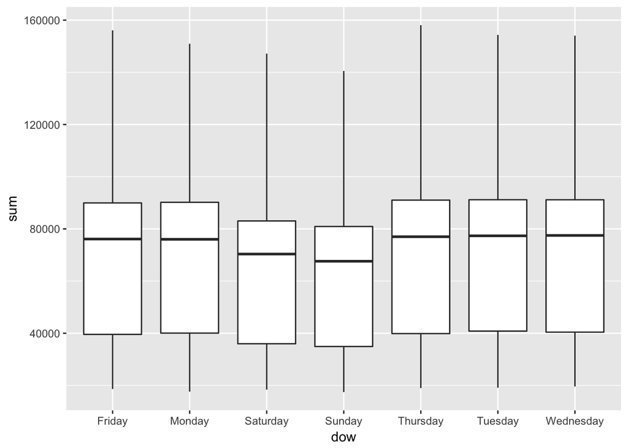

```r
pjm_est$dow <- weekdays(as.Date(pjm_est$Datetime))
ggplot(pjm_est, aes(x=dow, y=sum)) + geom_boxplot()
```

## Day of the month visualization

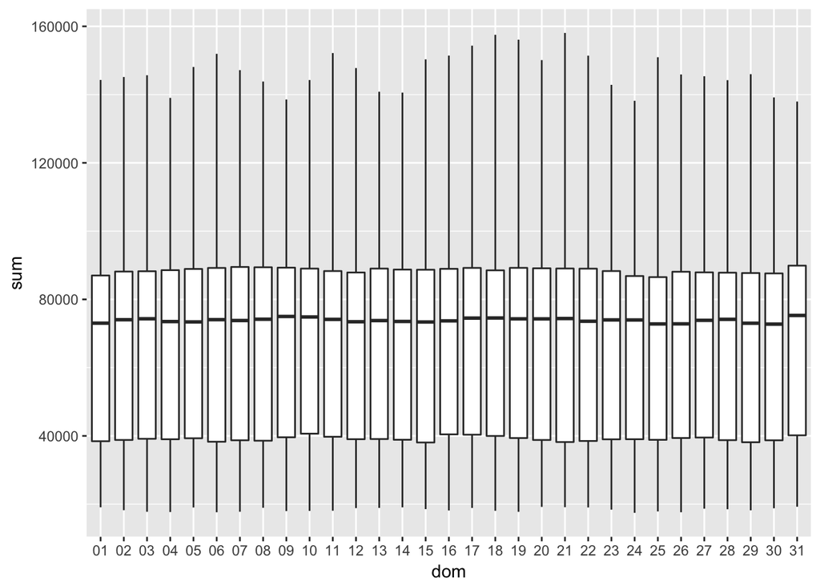

```r
pjm_est$dom <- strftime(as.Date(pjm_est$Date), format= "%d")
ggplot(pjm_est, aes(x=dom, y=sum)) + geom_boxplot()
```

We can see that the fluctuations during the week is possibly what generates a fluctuation during the month.

## Full month visualization

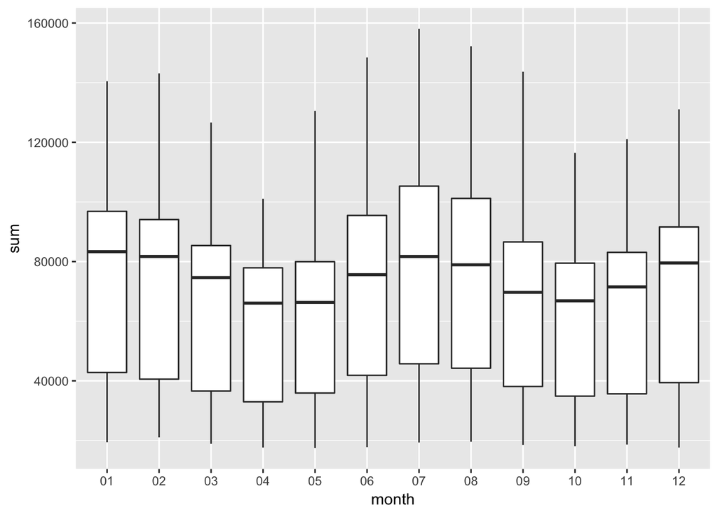

```r
pjm_est$month <- strftime(as.Date(pjm_est$Date), format="%m")
ggplot(pjm_est, aes(x=month, y=sum)) + geom_boxplot()
```

## Hour of the day visualization

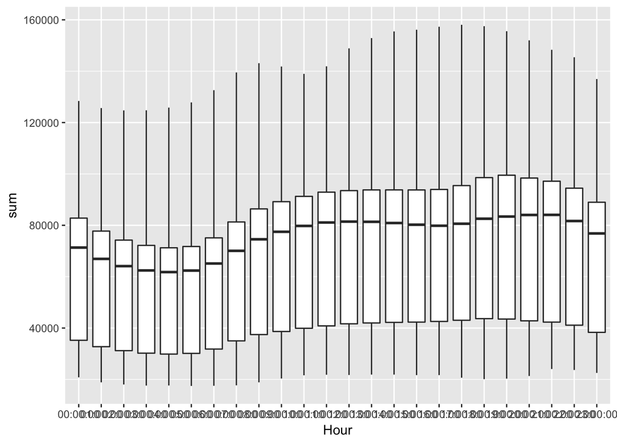

```r
ggplot(pjm_est, aes(x=Hour, y=sum)) + geom_boxplot()
```

Work hours are the ones that consume the most energy, as was expected

Lets check if the the behaviour during winter is the same as during summer.

# Winter vs Summer

```r
verao <- subset(pjm_est, month=='07')
inverno <- subset(pjm_est, month=='01')
nrow(verao)
```

```
## [1] 15624
```

```r
nrow(inverno)
```

```
## [1] 14880
```

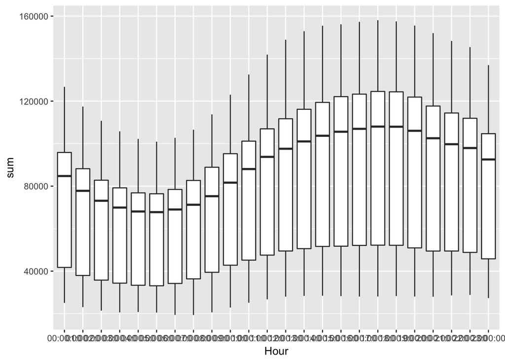

```r
ggplot(verao, aes(x=Hour, y=sum)) + geom_boxplot()
```

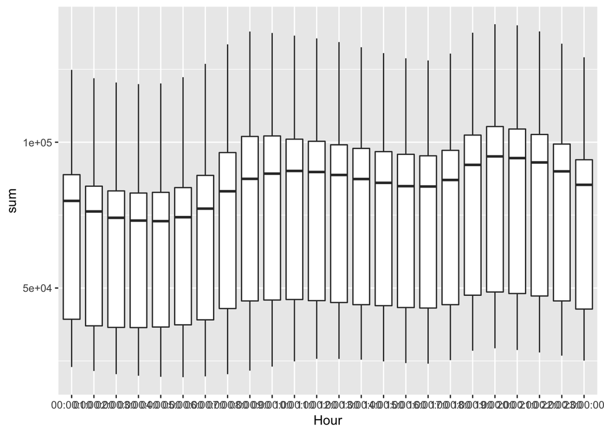

```r
ggplot(inverno, aes(x=Hour, y=sum)) + geom_boxplot()
```

During winter the energy consumption is more stable during the day, while in the summer there are more peaks

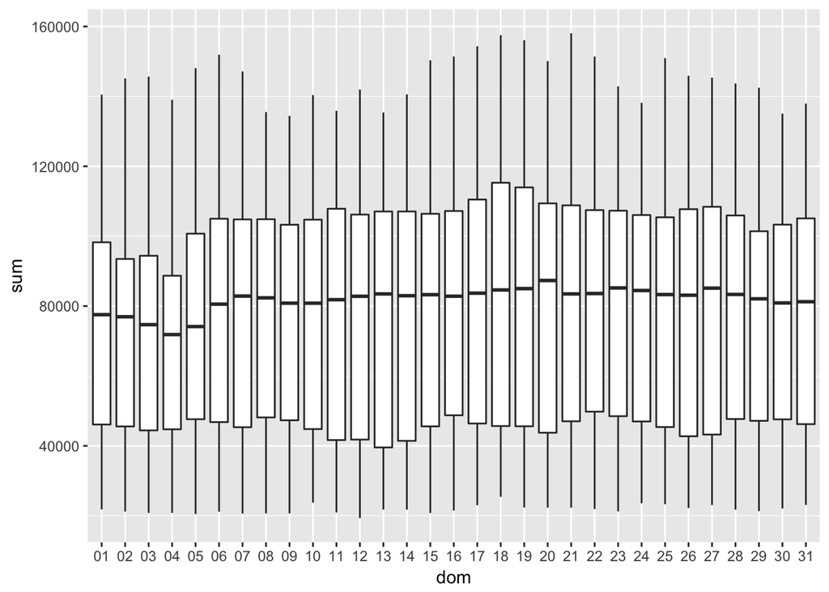

```r
ggplot(verao, aes(x=dom, y=sum)) + geom_boxplot()
```

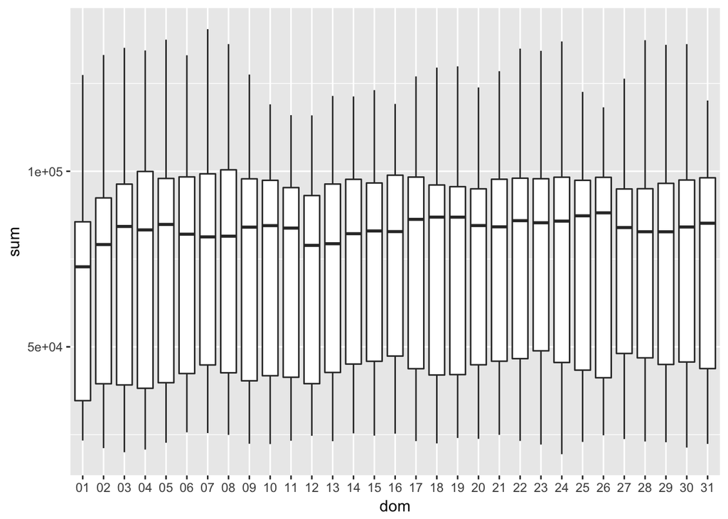

```r
ggplot(inverno, aes(x=dom, y=sum)) + geom_boxplot()
```

Month behaviour is approximately the same.

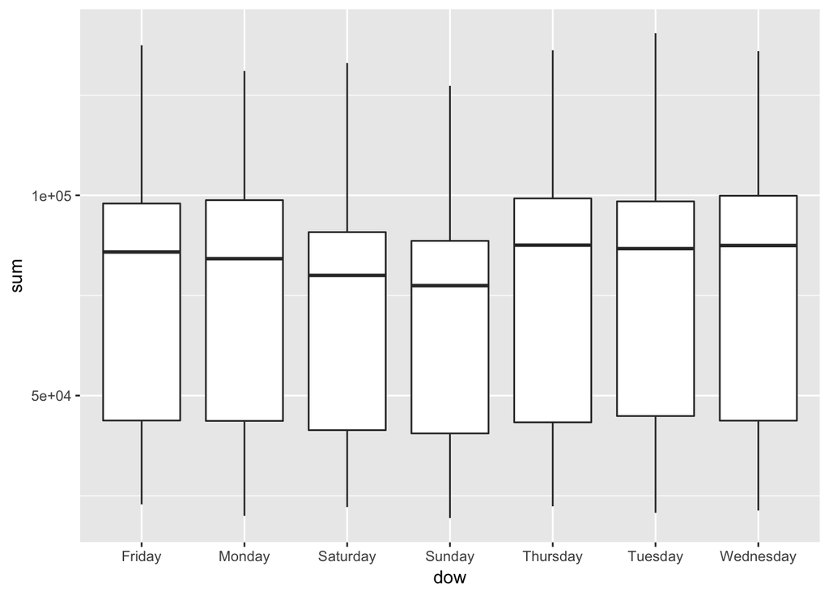

```r
ggplot(inverno, aes(x=dow, y=sum)) + geom_boxplot()
```

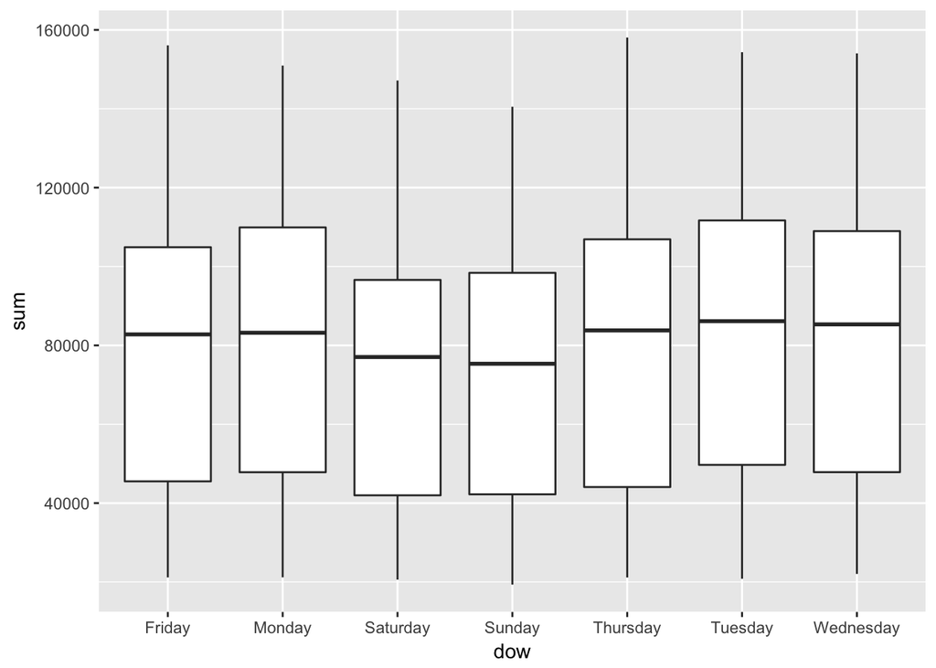

```r
ggplot(verao, aes(x=dow, y=sum)) + geom_boxplot()
```

Week behaviour is also similar

Summer vacations seem to not change much the energy consumption.

## Temporal series

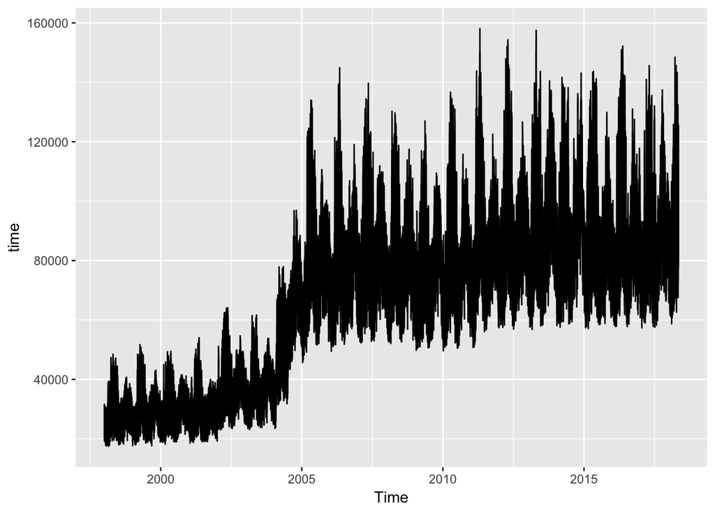

```r
train_sample <- setDT(pjm_est)
time <- ts(train_sample[,"sum"], start=1998,frequency=365*24)
autoplot(time)
```

Too much variation until 2005. The company grew a lot and that may bias the predictor. Lets get a subset of the data.

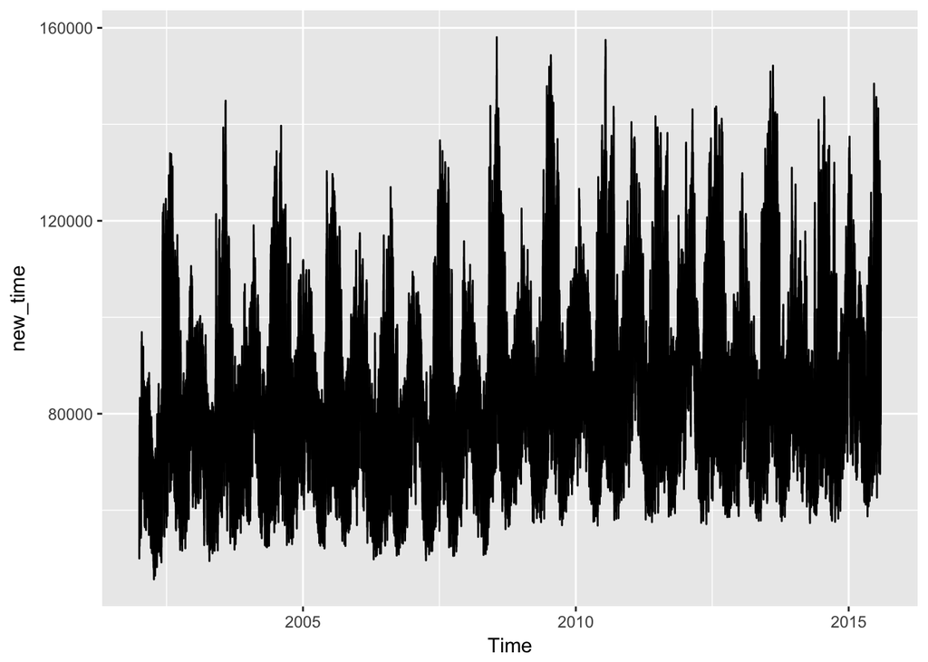

```r
pjm_est$Date <- as.Date(pjm_est$Date)
df <- subset(pjm_est, Date > as.Date("2005-01-01"))
new_tra <- setDT(df)
new_time <- ts(new_tra[,"sum"], start=2002, frequency=365*24)
autoplot(new_time)
```

Other good alternative would be to get a smaller region like PJM East.

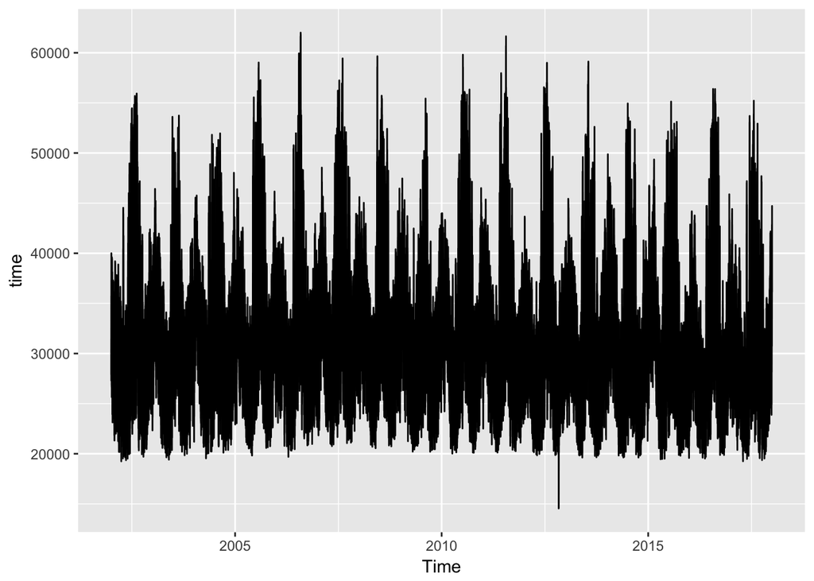

```r
pjme <- pjm_est[,c(1,11,14,15,16,17,18,19)]
pjme <- pjme[complete.cases(pjme),]
tra <- setDT(pjme)
time <- ts(tra[,"PJME"], start=2002, end=2018, frequency=365*24)
autoplot(time)
```

However, we can see that PJME’s behaviour is much different from the company as a whole.

```r
summary(pjm_est$PJME/pjm_est$sum)
```

```
##    Min. 1st Qu.  Median    Mean 3rd Qu.    Max.    NA's
##    0.23    0.35    0.39    0.45    0.42    1.00   32896
```

```r
nrow(pjme)/nrow(pjm_est)
```

```
## [1] 0.8154626
```

```r
nrow(df)/nrow(pjm_est)
```

```
## [1] 0.6678092
```

A more complex analysis could make a predictor for every region by itself, or considering that hollidays may change consumption. However, in this notebook I will make a simple predictor without any of this hypotesis.

# Predictive Analysis

```r
splitting_date <- as.Date('2014-06-01')
ts_df <- ts(df[,"sum"], frequency=365*24)
train <- subset(ts_df, end=length(ts_df)-365*24*3.5)

length(train)/length(ts_df)
```

```
## [1] 0.7424503
```

## Checking if residuals are white noise

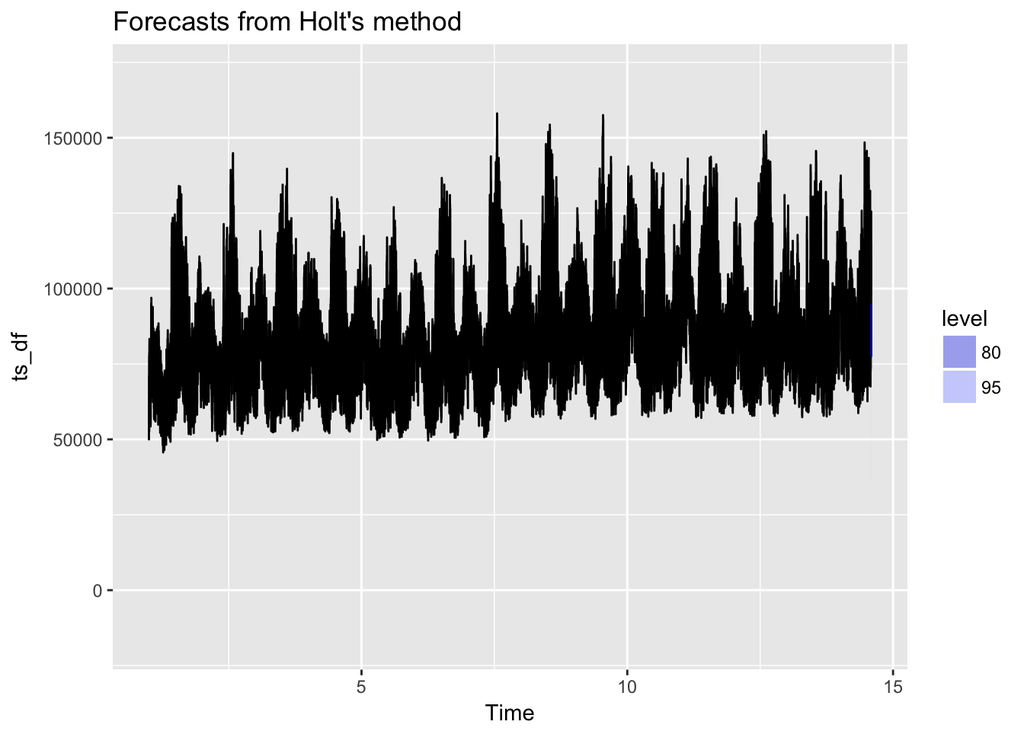

```r
holt_model <- holt(ts_df)
autoplot(holt_model)
```

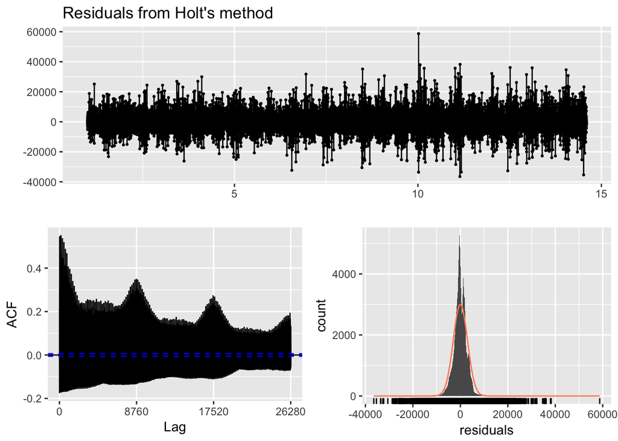

```
##
##  Ljung-Box test
##
## data:  Residuals from Holt's method
## Q* = 17712000, df = 17516, p-value < 2.2e-16
##
## Model df: 4.   Total lags used: 17520
```

```r
checkresiduals(holt_model)
```

p-value < 0.05, the trends are probably not white noise.

# Testing different predictive algorithms

## Naive Model

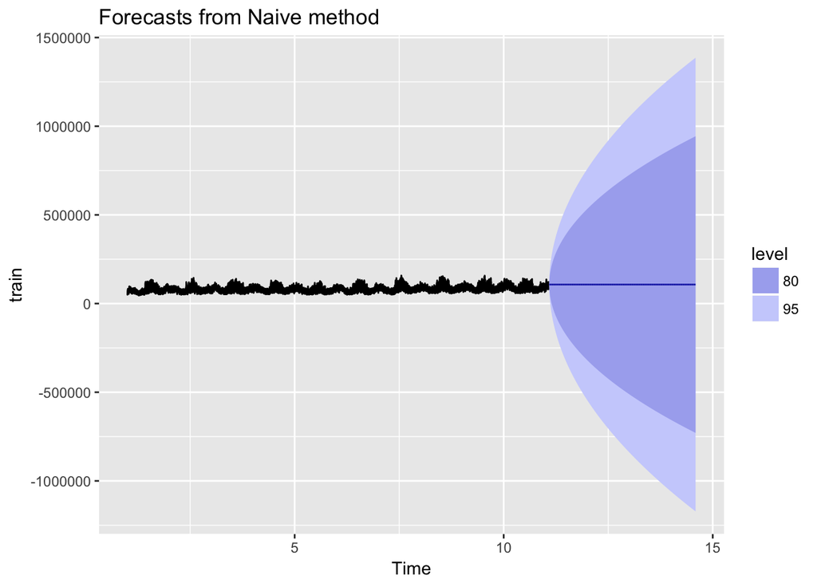

```r
nv <- naive(train, h=3.5*365*24)
autoplot(nv)
```

```r
accuracy(nv, ts_df)
```

```
##                         ME      RMSE       MAE         MPE      MAPE
## Training set  6.011043e-01  3726.899  2707.098  -0.1032213  3.305391
## Test set     -1.726391e+04 24121.310 21055.623 -23.2692867 26.295077
##                   MASE      ACF1 Theil's U
## Training set 0.2669443 0.6653769        NA
## Test set     2.0762744 0.9731637   7.34179
```

## ETS Model

```r
fcets <- ets(train)
```

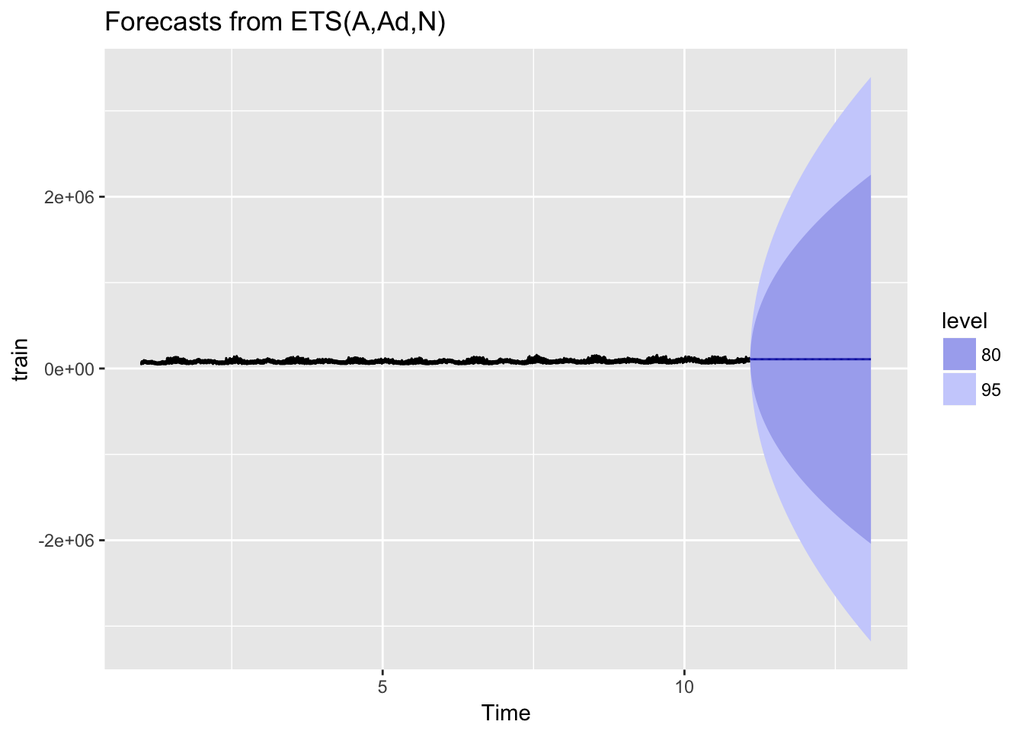

```r
autoplot(forecast(fcets))
```

```r
accuracy(forecast(fcets), ts_df)
```

```
##                         ME      RMSE       MAE          MPE      MAPE
## Training set  1.356006e-01  2783.197  1809.176   0.09689396  2.241515
## Test set     -1.785634e+04 24850.873 21699.989 -24.10972690 27.156474
##                   MASE         ACF1 Theil's U
## Training set 0.1784011 0.0004892872        NA
## Test set     2.1398148 0.9738288159   7.49602
```

## PROPHET Model

```r
splitting_date <- as.Date('2014-06-01')
train_df <- subset(df, Date < splitting_date)
stats = data.frame(y=log1p(train_df$sum), ds=train_df$Datetime)
stats = aggregate(stats$y, by=list(stats$ds), FUN=sum) # juntando se houverem 2 datetimes iguais
colnames(stats) <- c("ds", "y")
head(stats)
```

```
##                    ds        y
## 1 2005-01-02 00:00:00 10.95811
## 2 2005-01-02 01:00:00 10.89637
## 3 2005-01-02 02:00:00 10.85190
## 4 2005-01-02 03:00:00 10.82947
## 5 2005-01-02 04:00:00 10.81958
## 6 2005-01-02 05:00:00 10.82365
```

```r
proph = prophet(stats)
```

```
## Initial log joint probability = -21.7296
## Optimization terminated normally:
##   Convergence detected: relative gradient magnitude is below tolerance
```

### Preparing test dataset

```r
test_df <- subset(df, Date >= splitting_date)
test = data.frame(y=log1p(test_df$sum), ds=test_df$Datetime)
test = aggregate(test$y, by=list(test$ds), FUN=sum) # juntando se houverem 2 datetimes iguais
colnames(test) <- c("ds", "y")
```

### Making prediction

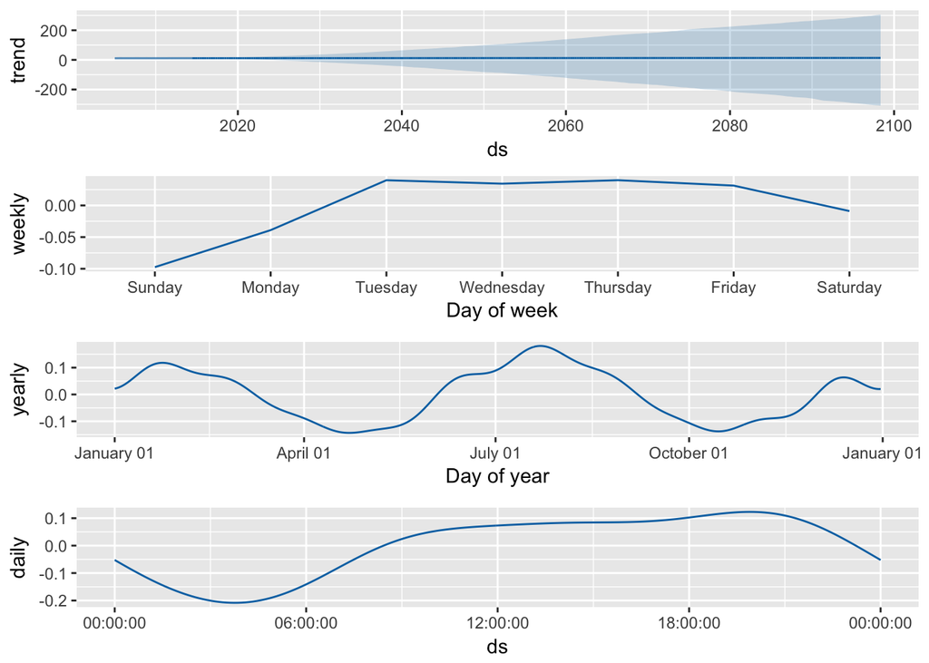

```r
future = make_future_dataframe(proph, periods=3.5*365*24)
prediction = predict(proph, future)
mean_pred = prediction[,c("ds", "yhat")]

prophet_plot_components(proph, prediction)
```

### Retransforming data to MW

```r
mean_pred$yhat = expm1(mean_pred$yhat)
head(mean_pred)
```

```
##                    ds     yhat
## 1 2005-01-02 00:00:00 58106.06
## 2 2005-01-02 01:00:00 54426.46
## 3 2005-01-02 02:00:00 51633.49
## 4 2005-01-02 03:00:00 49967.66
## 5 2005-01-02 04:00:00 49602.14
## 6 2005-01-02 05:00:00 50652.96
```

### Calculating accuracy.

```r
ts_pred <- ts(mean_pred[,"yhat"], frequency=365*24)
ts_test <- ts(test_df[, "sum"], frequency=365*24)
ts_pred <- subset(ts_pred, end=length(ts_test)) # deixando ambos com mesmo tamanho pois a predic??o foi feita com valor aproximado de per??odos
accuracy(ts_pred, ts_test)
```

```
##                ME     RMSE      MAE      MPE     MAPE      ACF1 Theil's U
## Test set 9683.807 19868.72 15464.98 8.657309 16.33246 0.9693361  4.510673
```

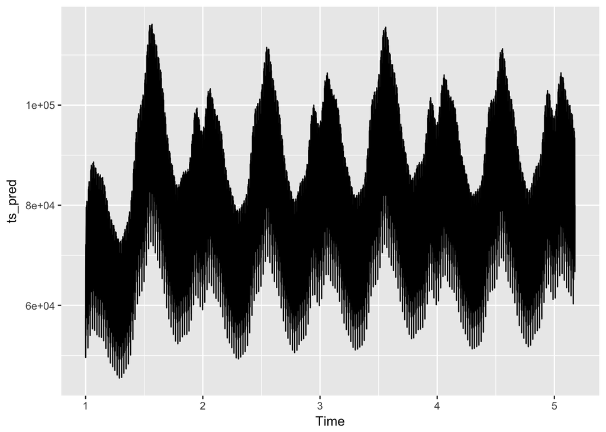

```r
autoplot(ts_pred)
```

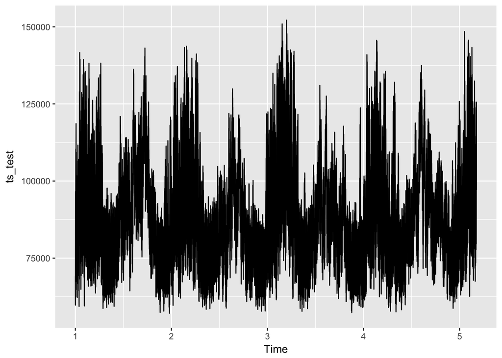

```r
autoplot(ts_test)
```